# MOFAmodel survival analysis

### Load MOFA model RNA and proteome data

```r
# Load the MOFA model
model_path <- "../Results/MOFA_models/mofa_cptac_pdac_rna_proteome_model.hdf5"
MOFAmodel <- load_model(model_path)
summary(MOFAmodel)
```

```
## Length  Class   Mode
##      1   MOFA     S4
```

### Get factor values and weights as data frames

```r
factors_df <- get_factors(MOFAmodel, factors = 'all')
# convert factors_df to dataframe and drop 'group1.' from column names
factors_df <- as.data.frame(factors_df)
colnames(factors_df) <- gsub('group1.', '', colnames(factors_df))
head(factors_df)
```

```
##              Factor1      Factor2    Factor3    Factor4    Factor5     Factor6
## C3N.03884 -1.3860456  3.356081009 -1.0197442 -0.2826568  0.2024496 -0.15327327
## C3L.04027  4.1362109  3.445488930 -0.8053722  6.9683285 -1.4657739 -1.20171809
## C3N.04283 -0.8911427  3.560000658  0.1541962 -2.1740761 -0.5232603  0.62358636
## C3L.04475  5.7104983 -0.085029945  0.9767969 -1.4330001  4.4993801  0.72225112
## C3N.00517  2.7935352 -2.416627169 -1.4514058 -1.5056711 -2.9201150 -1.19602799
## C3L.01037 -1.2013335 -0.002922298  1.3791745 -0.4307127 -0.4923555  0.09577906
```

```r
lapply(factors_df,dim)
```

```r
weights <- get_weights(MOFAmodel, views = "all", factors = "all")
lapply(weights,dim)
```

```
## $RNA
## [1] 5000    6
##
## $Protein
## [1] 5000    6
```

### Load clinical data

```r
clinical_df <- read.csv("../Data/Metadata/metadata_merged_clinical_mol-phenotype_from_paper.csv",
                        row.names = 1,
                        stringsAsFactors = FALSE,
                        na.strings = c("", " ", "NA", "N/A", "na", "null", "NULL", "NaN"))
cat("Before replacement:\n")
```

```
## Before replacement:
```

```r
print(head(rownames(clinical_df)))
```

```
## [1] "C3L-00102" "C3L-00189" "C3L-00277" "C3L-00401" "C3L-00640" "C3L-00819"
```

```r
# replace '-' with '.' in case IDs to match sample IDs in MOFA data
rownames(clinical_df) <- gsub("-", ".", rownames(clinical_df))

cat("\nAfter replacement:\n")
```

```
##
## After replacement:
```

```r
print(head(rownames(clinical_df)))
```

```
## [1] "C3L.00102" "C3L.00189" "C3L.00277" "C3L.00401" "C3L.00640" "C3L.00819"
```

```r
print(dim(clinical_df))
```

```
## [1] 140  94
```

### Survival data

```r
# select relevant columns: case ID, OS_days, OS_event
surv_df <- clinical_df %>%
  select(OS_days, OS_event) %>%
  mutate(OS_days = as.numeric(OS_days), OS_event = as.numeric(OS_event))
```

### Combine factors with survival data

```r
# samples are rows in factors_df and surv_df
combined_df <- merge(factors_df, surv_df, by = "row.names")
rownames(combined_df) <- combined_df$Row.names
combined_df$Row.names <- NULL
print(dim(combined_df))
```

```
## [1] 140   8
```

```r
head(combined_df)
```

```
##               Factor1     Factor2     Factor3    Factor4    Factor5     Factor6
## C3L.00017  0.09984452 -0.75784618  1.61187232 -0.6021509  1.3694342 -1.28022456
## C3L.00102 -1.22408998 -0.29151553 -0.06835844  0.2962598  0.4238291  0.49974144
## C3L.00189 -1.43758249 -0.01919632 -0.19109514  1.5454330 -0.5854980  1.91606987
## C3L.00277 -1.14540958  0.52072668  1.99262786 -2.6732609  0.8065475  0.63130260
## C3L.00401 -0.32924864  0.64645505 -0.79544169  0.8054718 -0.7091054  0.26912764
## C3L.00589 -0.77357095 -1.07151604  0.40764147 -1.5204901  0.9987742 -0.06455494
##           OS_days OS_event
## C3L.00017     426        0
## C3L.00102     249        1
## C3L.00189    1036        1
## C3L.00277     610        1
## C3L.00401    1262        1
## C3L.00589    1752        0
```

### Survival analysis

```r
# Fit Cox proportional hazards model for each factor
results <- data.frame(Factor = character(),
                        HR = numeric(),
                        pval = numeric(),
                        adj_pval = numeric(),
                        stringsAsFactors = FALSE
)
for (factor in colnames(factors_df)) {
  cox_model <- coxph(Surv(OS_days, OS_event) ~ combined_df[[factor]], data = combined_df)
  cox_summary <- summary(cox_model)
  hr <- cox_summary$coefficients[,"exp(coef)"]
  pval <- cox_summary$coefficients[,"Pr(>|z|)"]
  results <- rbind(results, data.frame(Factor = factor, HR = hr, pval = pval))
}
results$adj_pval <- p.adjust(results$pval, method = "BH")
print(results)
```

```
##    Factor        HR        pval    adj_pval
## 1 Factor1 1.0010676 0.985422249 0.985422249
## 2 Factor2 1.1924153 0.001315919 0.007895516
## 3 Factor3 0.9195228 0.468221180 0.561865416
## 4 Factor4 0.9428312 0.373704260 0.560556390
## 5 Factor5 0.8438996 0.017010672 0.051032017
## 6 Factor6 1.1543288 0.195377463 0.390754927
```

```r
# Identify significant factors
significant_factors <- results %>% filter(adj_pval < 0.05)
print(significant_factors)
```

```
##    Factor       HR        pval    adj_pval
## 1 Factor2 1.192415 0.001315919 0.007895516
```

If HR > 1: For every unit increase in Factor 2, the risk of the event (death) increases by (HR - 1) x 100. If your HR is 1.5, there is a 50% increase in risk per unit of Factor 2. If HR < 1: Factor 2 is protective.

### Proportional hazards assumption check

```r
for (factor in significant_factors$Factor) {
  cox_model <- coxph(Surv(OS_days, OS_event) ~ combined_df[[factor]], data = combined_df)
  ph_test <- cox.zph(cox_model)
  print(paste("Proportional hazards test for", factor))
  print(ph_test)
}
```

```
## [1] "Proportional hazards test for Factor2"
##                       chisq df    p
## combined_df[[factor]]  1.85  1 0.17
## GLOBAL                 1.85  1 0.17
```

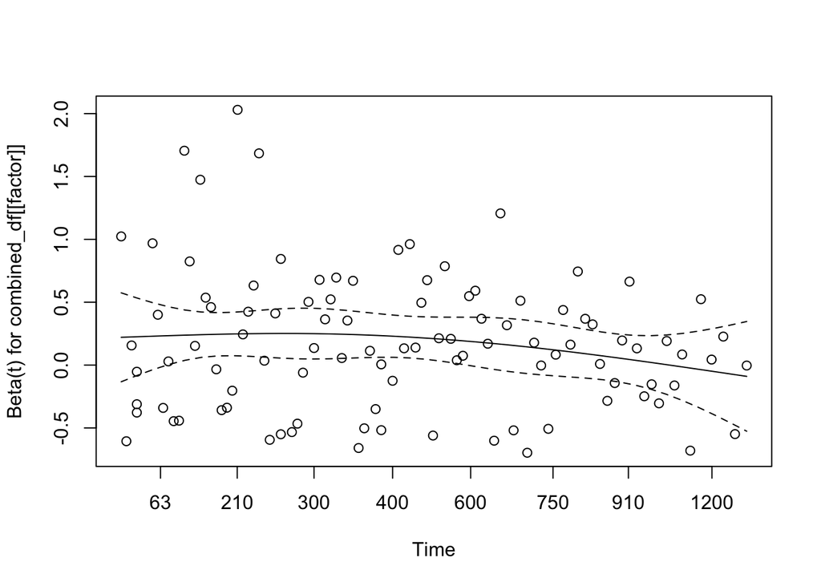

```r
# Example plot for the first significant factor
test.ph <- cox.zph(cox_model)
plot(test.ph) # Look for a horizontal line
```

Factor 2 was identified as a significant predictor of overall survival in a Cox proportional hazards model. The proportional hazards assumption was verified both visually via Schoenfeld residual plots and statistically via the cox.zph test (chi^2 = 1.85, p = 0.17). In the context of a Schoenfeld residual test (the cox.zph() function in R), the null hypothesis is that the hazards are proportional. A p-value > 0.05 (like your 0.17) means you fail to reject the null hypothesis. Translation: There is no statistically significant evidence that the proportional hazards assumption has been violated. If this p-value had been, say, 0.001, it would mean the impact of Factor 2 changes drastically over time (e.g., it’s very dangerous in the first 6 months but doesn’t matter after 2 years). Chisq measures the “mismatch” between your data and the PH assumption. A low value is good.

### Kaplan-Meier survival curves for significant factors

```
## Ignoring unknown labels:
## • colour : "Strata"
```

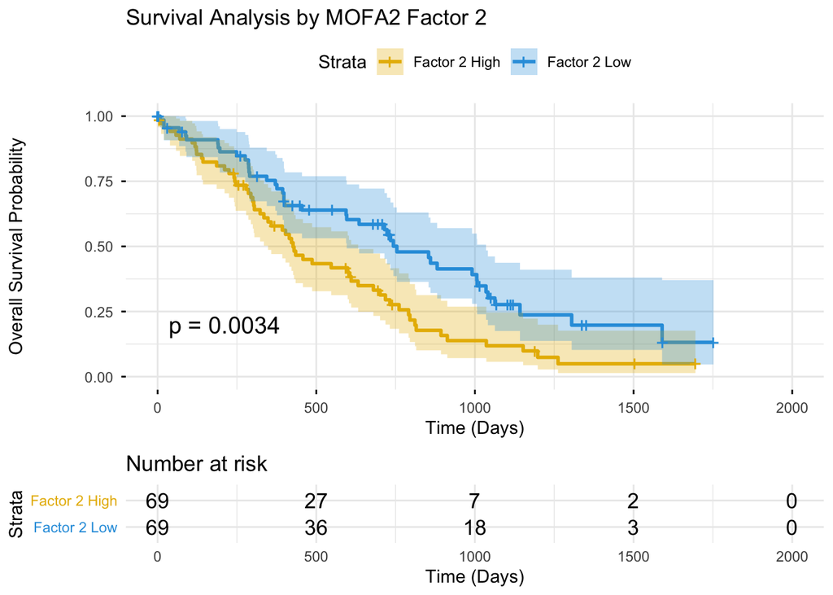

```r
# Binarize Factor 2 based on the median
median_f2 <- median(combined_df$Factor2, na.rm = TRUE)
combined_df$Factor2_group <- ifelse(combined_df$Factor2 > median_f2, "High", "Low")

# Fit survival curve
fit <- survfit(Surv(OS_days, OS_event) ~ Factor2_group, data = combined_df)

# Create plot
ggsurvplot(
  fit,
  data = combined_df,
  palette = c("#E7B800", "#2E9FDF"), # High = Gold, Low = Blue
  risk.table = TRUE,                # Add risk table below
  pval = TRUE,                      # Show p-value from log-rank test
  conf.int = TRUE,                  # Show confidence intervals
  xlab = "Time (Days)",
  ylab = "Overall Survival Probability",
  legend.labs = c("Factor 2 High", "Factor 2 Low"),
  title = "Survival Analysis by MOFA2 Factor 2",
  ggtheme = theme_minimal()
)
```

The log-rank p-value of 0.0034 confirms that the distinction between “Factor 2 High” and “Factor 2 Low” isn’t just a statistical artifact—it’s a major biological divider for patient outcomes in this cohort.

Observations from K-M Plot: Clear Separation: The yellow (“High”) and blue (“Low”) curves begin to diverge significantly around the 250-day mark. Median Survival: You can see that the median survival for the “Factor 2 High” group is roughly 400–450 days, whereas the “Factor 2 Low” group extends much further, crossing the 0.5 probability threshold closer to 800 days. Risk at 500 Days: Looking at the risk table, there are 36 patients at risk in the “Low” group at day 500, but only 27 in the “High” group. That rapid drop-off in the yellow line is classic for the more aggressive PDAC subtypes.

The shaded areas around survival lines represent the 95% Confidence Interval (CI) for the survival probability at any given time point. That is, if you repeat this study with a different sample of patients from the same population, the “true” survival curve would likely fall within that shaded region 95% of the time.

### Multivariate Cox model including clinical covariates

Fit a multivariate Cox proportional hazards model that includes Factor 2 along with clinical covariates such as tumor stage and PurIST subtype. This is to check if Factor 2 remains a significant and *independent* predictor of survival after adjusting for these known clinical factors; or is simply a surrogate for tumor stage.

$$h(t) = h_0(t) \exp(\beta_1
\text{Factor2} + \beta_2 \text{Stage_Grouped} + \beta_3
\text{PurIST_Subtype})$$

```r
# Merge clinical columns into combined_df by matching rownames
combined_df$tumor_stage_pathological <- clinical_df[rownames(combined_df), "tumor_stage_pathological"]
combined_df$PurIST_Subtype <- clinical_df[rownames(combined_df), "PurIST_Subtype"]

# Collapse tumor stages into broader categories for statistical power
combined_df <- combined_df %>%
mutate(
    Stage_Grouped = case_when(
        tumor_stage_pathological %in% c("Stage IA", "Stage IB", "Stage I") ~ "Stage_I",
        tumor_stage_pathological %in% c("Stage IIA", "Stage IIB", "Stage II") ~ "Stage_II",
        tumor_stage_pathological %in% c("Stage III", "Stage IV") ~ "Stage_III_IV",
        TRUE ~ NA_character_
    ),

    # Set Reference Levels (Critical for Cox model interpretation)
    Stage_Grouped = factor(Stage_Grouped, levels = c("Stage_I", "Stage_II", "Stage_III_IV")),

    # Ensure PurIST is a factor with 'Classical' as the baseline
    # (Update 'Basal-like' or 'Classical' if your labels are slightly different)
    PurIST_Subtype = factor(PurIST_Subtype, levels = c("classical", "basal-like"))
  )

# 3. Check for NAs that might be dropped in the model
print("Stage Distribution:")
```

```
## [1] "Stage Distribution:"
```

```r
print(table(combined_df$Stage_Grouped, useNA = "always"))
```

```
##
##      Stage_I     Stage_II Stage_III_IV         <NA>
##           23           60           51            6
```

```r
# Fit the multivariate model
# Note: R will automatically drop rows with NAs in these columns
multivar_cox <- coxph(
  Surv(OS_days, OS_event) ~ Factor2 + Stage_Grouped + PurIST_Subtype,
  data = combined_df
)

# View the detailed summary
summary(multivar_cox)
```

```
## Call:
## coxph(formula = Surv(OS_days, OS_event) ~ Factor2 + Stage_Grouped +
##     PurIST_Subtype, data = combined_df)
##
##   n= 134, number of events= 96
##    (6 observations deleted due to missingness)
##
##                              coef exp(coef) se(coef)     z Pr(>|z|)
## Factor2                   0.13407   1.14347  0.06694 2.003   0.0452 *
## Stage_GroupedStage_II     0.15848   1.17173  0.31431 0.504   0.6141
## Stage_GroupedStage_III_IV 0.49711   1.64396  0.31097 1.599   0.1099
## PurIST_Subtypebasal-like  0.31192   1.36604  0.30582 1.020   0.3078
## ---
## Signif. codes:  0 '***' 0.001 '**' 0.01 '*' 0.05 '.' 0.1 ' ' 1
##
##                           exp(coef) exp(-coef) lower .95 upper .95
## Factor2                       1.143     0.8745    1.0029     1.304
## Stage_GroupedStage_II         1.172     0.8534    0.6328     2.170
## Stage_GroupedStage_III_IV     1.644     0.6083    0.8937     3.024
## PurIST_Subtypebasal-like      1.366     0.7320    0.7502     2.488
##
## Concordance= 0.606  (se = 0.031 )
## Likelihood ratio test= 12.19  on 4 df,   p=0.02
## Wald test            = 12.98  on 4 df,   p=0.01
## Score (logrank) test = 13.26  on 4 df,   p=0.01
```

Hazard Ratio (The Magnitude of Risk) - the `exp(coef)` column: Factor 2 (1.143): For every 1-unit increase in the Factor 2 score, the risk of death increases by 14.3%. Because Factor scores are usually standardized, a multi-unit jump in the score represents a massive shift in patient risk. Stage III/IV (1.644): As expected, advanced stages have a higher hazard ratio (64% increased risk vs. Stage I), but interestingly, it isn’t statistically significant here (`p = 0.1099`), likely because the aggressive biology captured by Factor 2 is explaining the deaths better than the stage itself.

Model Reliability $n=134$, Events=96: a very healthy ratio of events to patients. Having 96 deaths gives the model enough “information” to make these calculations stable. Concordance (0.606): This is a moderate score. It means the model correctly predicts which of two patients will die first about 61% of the time. While not perfect, it’s quite standard for complex cancer cohorts. Likelihood ratio test (`p=0.02`): This tells us the model as a whole is significantly better at predicting survival than a model with no variables at all.

### Forest plot of multivariate Cox model

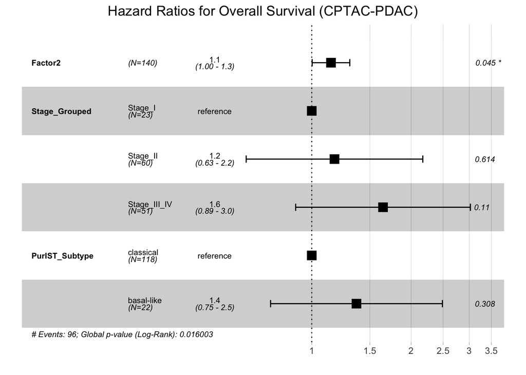

```r
# Generate the forest plot from your multivariate model
ggforest(multivar_cox, data = combined_df,
         main = "Hazard Ratios for Overall Survival (CPTAC-PDAC)",
         cpositions = c(0.02, 0.22, 0.4))
```

The Vertical Line (HR = 1): This is the “Null” line. If a variable’s horizontal bar (the 95% Confidence Interval) crosses this line, it is not statistically significant. Factor 2 whiskers (the CI) will likely be just touching or slightly clear of the 1.0 line on the right side. This visually confirms `p = 0.045`. The forest plot shows that Factor 2 is the most robust, consistent driver of risk in the model because it has the most “certainty” (narrower relative whiskers) compared to the noisy clinical staging.